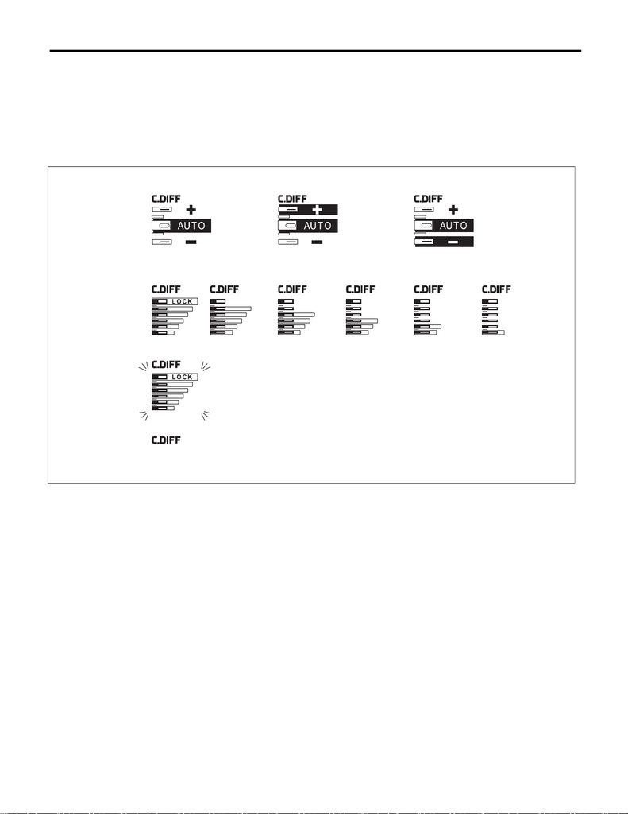

6MT(diag)-11

Drivers Control Center Differential (DCCD) Mode Display

MANUAL TRANSMISSION AND DIFFERENTIAL (DIAGNOSTICS)

10.Drivers Control Center Differential (DCCD) Mode Display

A: OPERATION

When there is a problem with a part or module, DCCD manual mode display blinks. (DCCD manual mode

display blinks even in AUTO mode condition.) The blinking starts when the problem is detected, and contin-

ues until the ignition switch is turned OFF. The faulty parts can be recognized by reading DTC with the Sub-

aru Select Monitor.

DCCD mode display is as shown in the figure.

(A) AUTO mode display (F) AUTO + (J) 4

(B) Manual mode display (G) AUTO – (K) 3

(C) If faulty (blinks at 1 Hz cycle) (H) 6 (LOCK) (L) 2

(D) At protection control (light off) (I) 5 (M) 1 (FREE)

(E) AUTO

MT-03119

(L )

(K)

(M)

(B)

(H)

(C)

(A)

(E) (F)

(G)

(D)

[figure not shown]

Drivers Control Center Differential (DCCD) Mode Display

MANUAL TRANSMISSION AND DIFFERENTIAL (DIAGNOSTICS)

B: INSPECTION

DIAGNOSIS:

• Defective CAN communication

• DCCD control module malfunction

• Combination meter malfunction

TROUBLE SYMPTOM:

DCCD mode display does not change even when the C.DIFF +/– switch is operated.

Step Check Yes No

1 CHECK COMBINATION METER.

Perform the self-diagnosis of combination

meter. <Ref. to IDI-9, INSPECTION, Combina-

tion Meter System.>

Is the self-diagnosis of combi-

nation meter OK?

Go to step 2. Repair it according

to combination

meter diagnostics.

2 CHECK IGNITION POWER SUPPLY CIRCUIT

OF DCCD CONTROL MODULE.

1) Connect the Subaru Select Monitor to the

vehicle.

2) Turn the ignition switch to ON.

3) Read the data of «Battery voltage» using

Subaru Select Monitor.

Is the voltage 10 V or more? Go to step 3. Repair the open

circuit of harness

between fuse (F/B

No. 12) and DCCD

control module, or

between fuse (F/B

No. 12) and bat-

tery.

3 CHECK DTC. Is DTC P0606 or U code dis-

played?

Perform the diag-

nosis according to

DTC.

Go to step 4.

4 CHECK MODE CHANGE SWITCH.

Read the data of «AUTO/MANUAL Mode

Switch» using the Subaru Select Monitor.

Does the display change to ON/

OFF according to the mode

change switch operation?

Go to step 5. Check the mode

change switch.

5 CHECK C.DIFF +/– SWITCH (UP/DOWN).

Read the data of «Up Switch» and «Down

Switch» using the Subaru Select Monitor.

Does the display change to

ON/OFF according to the

C.DIFF +/– switch operation?

Go to step 6. Check the C.DIFF

+/– switch.

6 CHECK REAR DIFFERENTIAL OIL TEMPER-

ATURE WARNING LIGHT.

Is the rear differential oil tem-

perature warning light blinking?

Check the rear dif-

ferential oil temper-

ature sensor.

Go to step 7.

7 CHECK REAR DIFFERENTIAL OIL TEMPER-

ATURE WARNING LIGHT.

Does the rear differential oil

temperature warning light illu-

minate?

Protection control

is ON due to high

rear differential oil

temperature. Per-

form the inspection

again after rear dif-

ferential oil temper-

ature lowers.

Go to step 8.

8 CHECK AWD LIGHT. Is the AWD light off? Go to step 9. Perform the diag-

nosis according to

AWD light display.

9 CHECK DCCD AUTO MODE DISPLAY.

Set to AUTO mode by pressing the mode

change switch.

Does the DCCD AUTO mode

display illuminate?

Go to step 10. Replace the DCCD

control module.

<Ref. to

6MT(TY85)-36,

Driver’s Control

Center Differential

Control Module.>

10 CHECK DCCD AUTO MODE DISPLAY.

Read the data of «DCCD Mode» using Subaru

Select Monitor.

Does the DCCD AUTO mode

display change according to the

C.DIFF +/– switch operation?

Go to step

11. Replace the DCCD

control module.

<Ref. to

6MT(TY85)-36,

Driver’s Control

Center Differential

Control Module.>

[figure not shown]

Drivers Control Center Differential (DCCD) Mode Display

MANUAL TRANSMISSION AND DIFFERENTIAL (DIAGNOSTICS)

11 CHECK INDICATION OF DCCD MANUAL

MODE DISPLAY.

Press the mode change switch to enter the

manual mode.

Does the DCCD manual mode

display illuminate?

Go to step 12. Replace the DCCD

control module.

<Ref. to

6MT(TY85)-36,

Driver’s Control

Center Differential

Control Module.>

12 CHECK INDICATION OF DCCD MANUAL

MODE DISPLAY.

Read the data of «DCCD Torque Allocation»

using the Subaru Select Monitor.

Does the DCCD manual mode

display change according to the

C.DIFF +/– switch operation?

Go to step 13. Replace the DCCD

control module.

<Ref. to

6MT(TY85)-36,

Driver’s Control

Center Differential

Control Module.>

13 CHECK OTHER DTC. Is any other DTC displayed? Perform the diag-

nosis according to

DTC.

DCCD mode dis-

play is normal.

Step Check Yes No